# Classifying the Perceived Health of New York City Street Trees

Author

STAT5003 W12G04

# 1 Framing & Dataset Selection

## 1.1 Research question and motivation

**Research question:** *To what extent can observable tree characteristics, site conditions, and geographic information classify the perceived health of living New York City street trees as Good, Fair, or Poor?*

This is a multi-class classification problem with practical relevance to the New York City Department of Parks and Recreation (NYC Parks), local councils, community tree stewards, and residents. A reliable model could support the prioritisation of professional inspections and maintenance when it is not feasible to inspect every tree simultaneously. It should be treated as a screening tool rather than an arboricultural diagnosis because the outcome is the census worker’s *perception* of health, not a laboratory measurement (New York City Department of Parks and Recreation [NYC Parks], 2016). The analysis is predictive and observational; associations must not be interpreted as causal effects.

```r
library(readr)
library(dplyr)
library(tidyr)
library(ggplot2)
library(forcats)
library(scales)
library(patchwork)
library(knitr)

data_file <- "2015_Street_Tree_Census_-_Tree_Data.csv"

trees_raw <- read_csv(
  data_file,
  na = c("", "NA", "N/A", "NULL"),
  show_col_types = FALSE,
  progress = FALSE
)

issue_vars <- c(
  "root_stone", "root_grate", "root_other",
  "trunk_wire", "trnk_light", "trnk_other",
  "brch_light", "brch_shoe", "brch_other"
)

trees <- trees_raw |>
  filter(status == "Alive", health %in% c("Good", "Fair", "Poor")) |>
  mutate(
    health = factor(health, levels = c("Good", "Fair", "Poor")),
    problem_count = rowSums(
      across(all_of(issue_vars), ~ .x == "Yes"),
      na.rm = TRUE
    ),
    problem_group = factor(
      if_else(problem_count >= 3, "3+", as.character(problem_count)),
      levels = c("0", "1", "2", "3+")
    )
  )

health_cols <- c(Good = "#2E7D32", Fair = "#F9A825", Poor = "#C62828")

theme_set(
  theme_minimal(base_size = 10) +
    theme(
      plot.title = element_text(face = "bold", size = 11),
      plot.subtitle = element_text(size = 9),
      panel.grid.minor = element_blank(),
      legend.position = "bottom"
    )
)
```

# 2 Consider & Gather Data

## 2.1 Source and scope

The data are the **2015 Street Tree Census–Tree Data**, collected by volunteers and staff coordinated by NYC Parks and partner organisations. The census records species, diameter, site conditions, perceived health, and location for individual street-tree points. Data collection ran from May 2015 to October 2016, so the data represent a historical snapshot rather than the current condition of New York City’s trees (NYC Parks, 2024). The dataset and data dictionary were obtained from the official [NYC Open Data portal](https://data.cityofnewyork.us/Environment/2015-Street-Tree-Census-Tree-Data/uvpi-gqnh), not Kaggle, an R built-in dataset, or course material.

Health is undefined for dead trees and stumps. We therefore restrict the classification cohort to living trees with a recorded Good, Fair, or Poor health label. This leaves 652,172 observations; only one living record is excluded because its health value is missing.

## 2.2 Suitability against the project requirements

```r
requirement_table <- tibble(
  Requirement = c("Large", "Messy", "Multi-class"),
  `Evidence in this dataset` = c(
    paste0(comma(nrow(trees_raw)), " rows and ", ncol(trees_raw),
           " columns; the CSV is approximately 285 MB."),
    paste0(
      comma(sum(is.na(trees_raw$health))),
      " missing health values, structurally concentrated among dead trees ",
      "and stumps; diameter also contains values requiring review."
    ),
    paste0(
      "Good/Fair/Poor outcome with class shares of ",
      percent(mean(trees$health == "Good"), accuracy = 0.1), ", ",
      percent(mean(trees$health == "Fair"), accuracy = 0.1), " and ",
      percent(mean(trees$health == "Poor"), accuracy = 0.1), "."
    )
  )
)

kable(requirement_table, caption = "Evidence that the dataset meets three project requirements")
```

Evidence that the dataset meets three project requirements

| Requirement | Evidence in this dataset |
| --- | --- |
| Large | 683,788 rows and 45 columns; the CSV is approximately 285 MB. |
| Messy | 31,616 missing health values, structurally concentrated among dead trees and stumps; diameter also contains values requiring review. |
| Multi-class | Good/Fair/Poor outcome with class shares of 81.1%, 14.8% and 4.1%. |

The dataset is not claimed to be **Complex** under the assignment definition because it has 45 rather than more than 100 features, and it is not claimed to be **Integrated** because no external data source has been joined. For computational efficiency, the 285 MB file is loaded once, summaries are vectorised, and later tree-based model tuning will use parallel processing and efficient implementations where available.

# 3 Exploratory Data Analysis

## 3.1 Missingness and outcome distribution

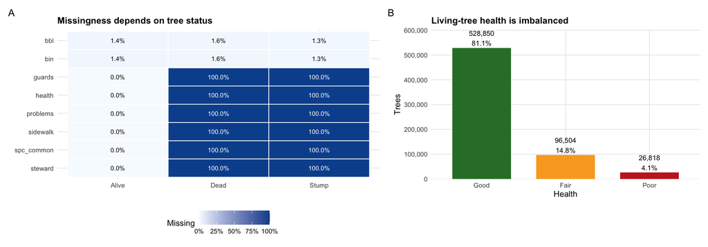

Figure 1: Structural missingness and health-class imbalance.

```r
missing_vars <- c(
  "health", "spc_common", "steward", "guards",
  "sidewalk", "problems", "bin", "bbl"
)

missing_by_status <- trees_raw |>
  group_by(status) |>
  summarise(across(all_of(missing_vars), ~ mean(is.na(.x))), .groups = "drop") |>
  pivot_longer(-status, names_to = "variable", values_to = "missing_rate") |>
  mutate(status = factor(status, levels = c("Alive", "Dead", "Stump")))

p_missing <- ggplot(
  missing_by_status,
  aes(x = status, y = fct_rev(variable), fill = missing_rate)
) +
  geom_tile(colour = "white", linewidth = 0.4) +
  geom_text(
    aes(
      label = percent(missing_rate, accuracy = 0.1),
      colour = missing_rate > 0.5
    ),
    size = 2.7,
    show.legend = FALSE
  ) +
  scale_colour_manual(values = c(`TRUE` = "white", `FALSE` = "black")) +
  scale_fill_gradient(
    low = "#F7FBFF", high = "#08519C", labels = label_percent()
  ) +
  labs(title = "Missingness depends on tree status", x = NULL, y = NULL,
       fill = "Missing")

class_dist <- trees |>
  count(health, name = "n") |>
  mutate(proportion = n / sum(n))

p_class <- ggplot(class_dist, aes(health, n, fill = health)) +
  geom_col(width = 0.7, show.legend = FALSE) +
  geom_text(
    aes(label = paste0(comma(n), "\n", percent(proportion, accuracy = 0.1))),
    vjust = -0.15,
    size = 3
  ) +
  scale_fill_manual(values = health_cols) +
  scale_y_continuous(
    labels = label_comma(), expand = expansion(mult = c(0, 0.14))
  ) +
  labs(title = "Living-tree health is imbalanced", x = "Health", y = "Trees")

(p_missing | p_class) +
  plot_layout(widths = c(1.2, 1)) +
  plot_annotation(tag_levels = "A")
```

The condition-related fields are almost entirely absent for Dead and Stump records because they were not applicable, rather than because of random data loss. After defining the living-tree cohort, the outcome remains strongly imbalanced: Good accounts for 81.1%, Fair 14.8%, and Poor only 4.1%. A trivial always-Good classifier would therefore achieve 81.1% accuracy, demonstrating why accuracy alone is unsuitable.

## 3.2 Univariate distributions and outliers

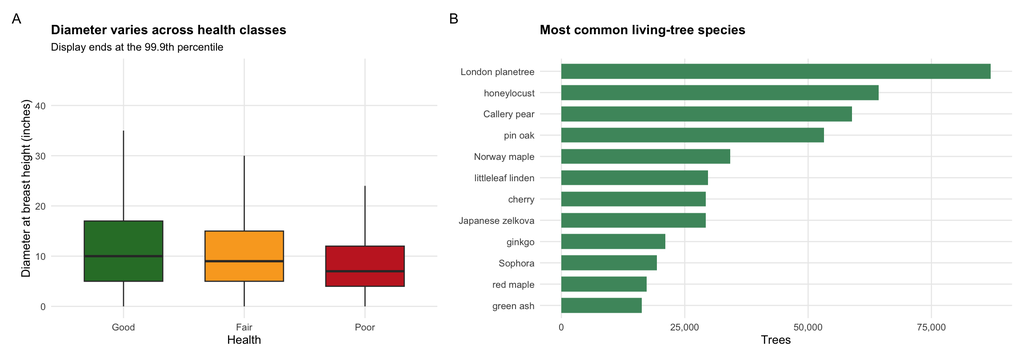

Figure 2: Distributions of diameter and common species. Extreme diameters are retained in the audit but omitted from the displayed scale.

```r
top_species <- trees |>
  count(spc_common, sort = TRUE, name = "n") |>
  slice_head(n = 12)

p_dbh <- ggplot(trees, aes(health, tree_dbh, fill = health)) +
  geom_boxplot(outlier.shape = NA, width = 0.65) +
  coord_cartesian(ylim = c(0, quantile(trees$tree_dbh, 0.999, na.rm = TRUE))) +
  scale_fill_manual(values = health_cols, guide = "none") +
  labs(title = "Diameter varies across health classes",
       subtitle = "Display ends at the 99.9th percentile",
       x = "Health", y = "Diameter at breast height (inches)")

p_species_count <- top_species |>
  mutate(spc_common = fct_reorder(spc_common, n)) |>
  ggplot(aes(n, spc_common)) +
  geom_col(fill = "#4C956C", width = 0.7) +
  scale_x_continuous(labels = label_comma()) +
  labs(title = "Most common living-tree species", x = "Trees", y = NULL)

(p_dbh | p_species_count) +
  plot_layout(widths = c(0.9, 1.1)) +
  plot_annotation(tag_levels = "A")
```

Median diameter is 10 inches (mean 11.7; 99th percentile 37), but the maximum is 425 inches. There are 222 living trees recorded with zero diameter and 67 above 100 inches. These observations require plausibility checks and sensitivity analysis; they should not be deleted solely because an automated outlier rule identifies them. Species is also concentrated: London planetree alone represents 87,014 living trees (13.3%).

## 3.3 Feature–outcome relationships

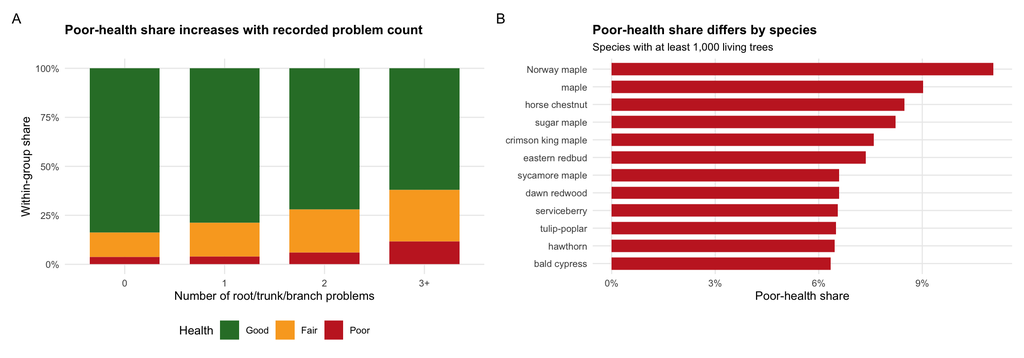

Figure 3: Health composition by recorded problem burden and observed Poor-health share by species.

```r
health_by_problem <- trees |>
  count(problem_group, health, .drop = FALSE, name = "n") |>
  group_by(problem_group) |>
  mutate(proportion = n / sum(n)) |>
  ungroup()

p_problem <- ggplot(
  health_by_problem,
  aes(problem_group, proportion, fill = health)
) +
  geom_col(width = 0.7) +
  scale_fill_manual(values = health_cols) +
  scale_y_continuous(labels = label_percent()) +
  labs(title = "Poor-health share increases with recorded problem count",
       x = "Number of root/trunk/branch problems", y = "Within-group share",
       fill = "Health")

species_poor <- trees |>
  count(spc_common, health, name = "n") |>
  group_by(spc_common) |>
  mutate(species_total = sum(n), proportion = n / species_total) |>
  ungroup() |>
  filter(health == "Poor", species_total >= 1000) |>
  slice_max(proportion, n = 12, with_ties = FALSE)

p_species_poor <- species_poor |>
  mutate(spc_common = fct_reorder(spc_common, proportion)) |>
  ggplot(aes(proportion, spc_common)) +
  geom_col(fill = health_cols[["Poor"]], width = 0.7) +
  scale_x_continuous(labels = label_percent()) +
  labs(title = "Poor-health share differs by species",
       subtitle = "Species with at least 1,000 living trees",
       x = "Poor-health share", y = NULL)

(p_problem | p_species_poor) +
  plot_layout(widths = c(1, 1)) +
  plot_annotation(tag_levels = "A")
```

Poor health rises from 3.6% among trees with no recorded problems to 11.7% among trees with three or more. Species differences are also substantial: 11.1% of Norway maples are recorded as Poor, compared with 4.1% overall. These are useful predictive signals, but confounding by age, location, observer, and other variables prevents a causal interpretation.

## 3.4 Feature–feature relationship

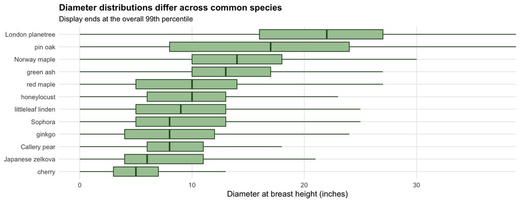

Figure 4: Diameter distributions across the twelve most common species (feature–feature relationship).

```r
trees |>
  filter(spc_common %in% top_species$spc_common) |>
  mutate(spc_common = fct_reorder(spc_common, tree_dbh, .fun = median)) |>
  ggplot(aes(tree_dbh, spc_common)) +
  geom_boxplot(outlier.shape = NA, fill = "#A7C7A1", colour = "#31572C") +
  coord_cartesian(xlim = c(0, quantile(trees$tree_dbh, 0.99, na.rm = TRUE))) +
  labs(title = "Diameter distributions differ across common species",
       subtitle = "Display ends at the overall 99th percentile",
       x = "Diameter at breast height (inches)", y = NULL)
```

The association between species and diameter suggests that predictors are not independent. Models that can represent non-linear relationships and interactions may therefore improve on a purely additive linear model.

# 4 Project Planning

## 4.1 Preprocessing and resampling plan

1. Retain living trees with a known outcome and preserve Good/Fair/Poor as a factor. Do not impute the outcome.
2. Remove direct identifiers (`tree_id`, address, BIN, and BBL), the constant `status`, inapplicable `stump_diam`, duplicate species name `spc_latin`, and raw `problems` text, which duplicates the nine issue indicators.
3. Retain `block_id` only as a resampling group. Split entire blocks between development and test sets so nearby trees from one block cannot appear in both. Keep the test set untouched until final evaluation.
4. Within each training fold, impute numeric predictors with the training median, encode unknown nominal values explicitly, pool rare species, and create dummy variables where required. Compare raw and `log1p` diameter and conduct a sensitivity analysis for implausible diameters.
5. Compare specifications with and without `user_type` and detailed geography to assess observer/process effects and dependence on location. Apply class weights or other imbalance treatment only inside training folds.

## 4.2 Candidate model plan

| Model | Suitability and role |
| --- | --- |
| Regularised multinomial logistic regression | Interpretable baseline; regularisation controls the expanded categorical design matrix. |
| Naive Bayes | Fast, scalable benchmark for a large dataset with many categorical predictors. Omit this model if the group has four members. |
| CART classification tree | Interpretable non-linear rules and interactions; pruning controls overfitting. |
| Random forest | Captures non-linearity and interactions while reducing single-tree variance (Breiman, 2001). |
| Gradient-boosted trees (XGBoost) | Flexible high-performance candidate; tune depth, learning rate, and number of trees (Chen & Guestrin, 2016). |

All models will use the same grouped split and grouped cross-validation folds. Hyperparameters and class weights will be selected using training resamples, not the final test set.

## 4.3 Evaluation plan

**Macro F1** will be the primary selection metric because it gives equal importance to all three classes. Secondary measures will include balanced accuracy, per-class precision and recall (especially Poor-class recall), multiclass log loss, and the confusion matrix. Overall accuracy will be reported only alongside the 81.1% majority-class benchmark. Probability calibration will also be inspected if the model is intended to prioritise inspections by risk score.

## 4.4 Timeline, responsibilities, and contingencies

| Milestone | Target | Lead | Backup/contingency |
| --- | --- | --- | --- |
| Confirm cohort, predictors, and EDA | Week 7-8 | Ziyan Chen | Anas Howera independently checks counts and figures. |
| Implement grouped split and preprocessing recipe | Week 9 | Chandrahaas Vellanki | Ziyan Chen reviews leakage and reproducibility. |
| Fit and tune candidate models | Week 10-11 | Harshita Singh, Uma Sree Asritha Adari, Anas Howera | Reduce tuning grid and parallelise if computation is excessive. |
| Compare models and perform sensitivity checks | Week 10-11 | Ziyan Chen, Uma Sree Asritha Adari | Chandrahaas Vellanki reproduces metrics from saved predictions. |
| Integrate report, references, and page-limit check | Week 10-11 | Harshita Singh | All members review; use the R Markdown version if Quarto is unavailable. |
| Final reproducibility run and submission | Week 12 | Ziyan Chen | A second member retains the final HTML and source files. |

# 5 References

Breiman, L. (2001). Random forests. *Machine Learning, 45*(1), 5–32. https://doi.org/10.1023/A:1010933404324

Chen, T., & Guestrin, C. (2016). XGBoost: A scalable tree boosting system. In *Proceedings of the 22nd ACM SIGKDD International Conference on Knowledge Discovery and Data Mining* (pp. 785–794). https://doi.org/10.1145/2939672.2939785

New York City Department of Parks and Recreation. (2016). *Street Tree Census 2015 trees data dictionary* [Data dictionary]. NYC Open Data. https://data.cityofnewyork.us/api/views/uvpi-gqnh/files/8705bfd6-993c-40c5-8620-0c81191c7e25?download=true

New York City Department of Parks and Recreation. (2024). *2015 Street Tree Census–Tree Data* [Data set]. NYC Open Data. https://data.cityofnewyork.us/Environment/2015-Street-Tree-Census-Tree-Data/uvpi-gqnh

## 5.1 AI Use Statement

We acknowledge the use of OpenAI Codex (GPT-5, OpenAI, https://openai.com/codex) to assist with structuring the report and drafting and debugging R code. All code, outputs, interpretations, citations, and final written content were reviewed and verified by the authors.